# Data 608 - Assignment 1

Matthew Lucich

2/4/2022

**Principles of Data Visualization and Introduction to ggplot2**

I have provided you with data about the 5,000 fastest growing companies in the US, as compiled by Inc. magazine. lets read this in:

```r
inc <- read.csv("https://raw.githubusercontent.com/charleyferrari/CUNY_DATA_608/master/module1/Data/inc5000_data.csv", header= TRUE)
```

And lets preview this data:

```r
head(inc)
```

```
##   Rank                         Name Growth_Rate   Revenue
## 1    1                         Fuhu      421.48 1.179e+08
## 2    2        FederalConference.com      248.31 4.960e+07
## 3    3                The HCI Group      245.45 2.550e+07
## 4    4                      Bridger      233.08 1.900e+09
## 5    5                       DataXu      213.37 8.700e+07
## 6    6 MileStone Community Builders      179.38 4.570e+07
##                       Industry Employees         City State
## 1 Consumer Products & Services       104   El Segundo    CA
## 2          Government Services        51     Dumfries    VA
## 3                       Health       132 Jacksonville    FL
## 4                       Energy        50      Addison    TX
## 5      Advertising & Marketing       220       Boston    MA
## 6                  Real Estate        63       Austin    TX
```

```r
summary(inc)
```

```
##       Rank          Name            Growth_Rate         Revenue
##  Min.   :   1   Length:5001        Min.   :  0.340   Min.   :2.000e+06
##  1st Qu.:1252   Class :character   1st Qu.:  0.770   1st Qu.:5.100e+06
##  Median :2502   Mode  :character   Median :  1.420   Median :1.090e+07
##  Mean   :2502                      Mean   :  4.612   Mean   :4.822e+07
##  3rd Qu.:3751                      3rd Qu.:  3.290   3rd Qu.:2.860e+07
##  Max.   :5000                      Max.   :421.480   Max.   :1.010e+10
##
##    Industry           Employees           City              State
##  Length:5001        Min.   :    1.0   Length:5001        Length:5001
##  Class :character   1st Qu.:   25.0   Class :character   Class :character
##  Mode  :character   Median :   53.0   Mode  :character   Mode  :character
##                     Mean   :  232.7
##                     3rd Qu.:  132.0
##                     Max.   :66803.0
##                     NA's   :12
```

Think a bit on what these summaries mean. Use the space below to add some more relevant non-visual exploratory information you think helps you understand this data:

```r
# Insert your code here, create more chunks as necessary
inc %>% summarise_all(n_distinct)
```

```
##   Rank Name Growth_Rate Revenue Industry Employees City State
## 1 4999 5001        1147    1069       25       692 1519    52
```

```r
colSums(is.na(inc))
```

```
##        Rank        Name Growth_Rate     Revenue    Industry   Employees
##           0           0           0           0           0          12
##        City       State
##           0           0
```

```r
describe(inc)
```

```
##             vars    n        mean           sd    median     trimmed
## Rank           1 5001     2501.64      1443.51 2.502e+03     2501.73
## Name*          2 5001     2501.00      1443.81 2.501e+03     2501.00
## Growth_Rate    3 5001        4.61        14.12 1.420e+00        2.14
## Revenue        4 5001 48222535.49 240542281.14 1.090e+07 17334966.26
## Industry*      5 5001       12.10         7.33 1.300e+01       12.05
## Employees      6 4989      232.72      1353.13 5.300e+01       81.78
## City*          7 5001      732.00       441.12 7.610e+02      731.74
## State*         8 5001       24.80        15.64 2.300e+01       24.44
##                     mad     min        max      range  skew kurtosis         se
## Rank            1853.25 1.0e+00 5.0000e+03 4.9990e+03  0.00    -1.20      20.41
## Name*           1853.25 1.0e+00 5.0010e+03 5.0000e+03  0.00    -1.20      20.42
## Growth_Rate        1.22 3.4e-01 4.2148e+02 4.2114e+02 12.55   242.34       0.20
## Revenue     10674720.00 2.0e+06 1.0100e+10 1.0098e+10 22.17   722.66 3401441.44
## Industry*          8.90 1.0e+00 2.5000e+01 2.4000e+01 -0.10    -1.18       0.10
## Employees         53.37 1.0e+00 6.6803e+04 6.6802e+04 29.81  1268.67      19.16
## City*            604.90 1.0e+00 1.5190e+03 1.5180e+03 -0.04    -1.26       6.24
## State*            19.27 1.0e+00 5.2000e+01 5.1000e+01  0.12    -1.46       0.22
```

## Question 1

Create a graph that shows the distribution of companies in the dataset by State (ie how many are in each state). There are a lot of States, so consider which axis you should use. This visualization is ultimately going to be consumed on a ‘portrait’ oriented screen (ie taller than wide), which should further guide your layout choices.

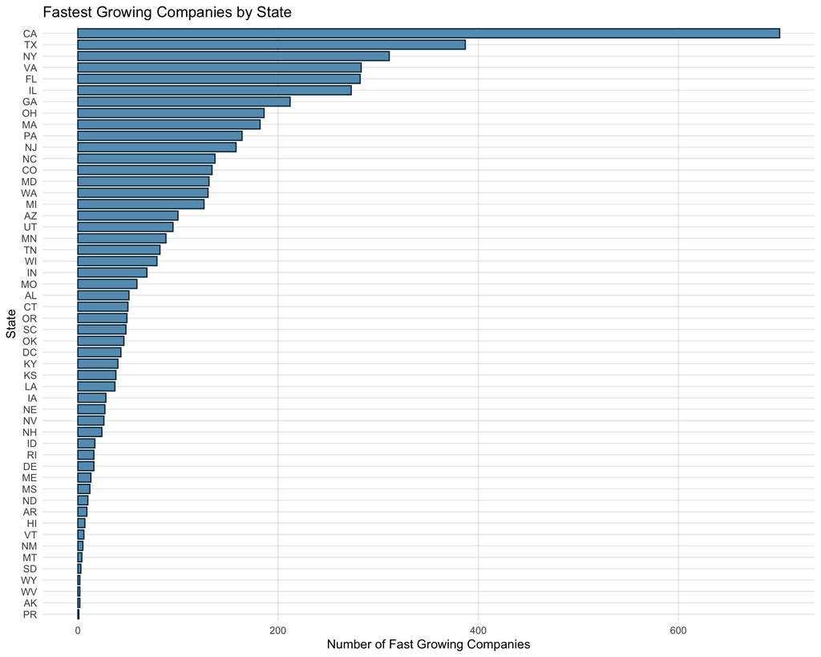

```r
# Answer Question 1 here
inc %>%
    group_by(State) %>%
    summarise(count = n()) %>%
    ggplot(aes(x = reorder(State,(count)), y = count)) +
        geom_bar(stat = "identity", color="#003049", fill="#669bbc", width=0.8) +
    theme(panel.background = element_rect(fill = NA),panel.grid.major = element_line(colour = "#555b6e20"),
                   axis.ticks = element_blank()) +
    coord_flip() + labs(title="Fastest Growing Companies by State", x ="State", y = "Number of Fast Growing Companies")
```

## Question 2

Lets dig in on the state with the 3rd most companies in the data set. Imagine you work for the state and are interested in how many people are employed by companies in different industries. Create a plot that shows the average and/or median employment by industry for companies in this state (only use cases with full data, use R’s `complete.cases()` function.) In addition to this, your graph should show how variable the ranges are, and you should deal with outliers.

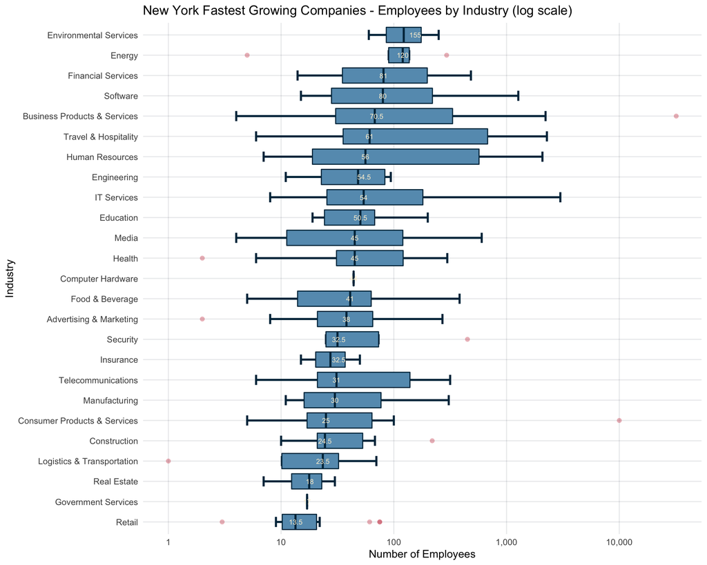

```r
# Answer Question 2 here
inc_ny <- inc %>%
  filter(complete.cases(.) & grepl('NY', State))

industry.median <- summarise(group_by(inc_ny, Industry), med = median(Employees))

options(scipen=10000)
ggplot(inc_ny, aes(x=reorder(Industry, Employees, median, na.rm = TRUE,), y=Employees)) +
    stat_boxplot(geom = "errorbar", width=0.5, size=1, color="#003049") +
    geom_boxplot(fill = "#669bbc", color="#003049", outlier.colour="#c1121f50", outlier.shape=16,
             outlier.size=2, notch=FALSE) +
             scale_y_log10(labels = scales::comma_format(accuracy = 1)) +
             theme(panel.background = element_rect(fill = NA),panel.grid.major = element_line(colour = "#555b6e20"),
                   axis.ticks = element_blank()) +
             geom_text(data = industry.median, aes(Industry, med, label = med),
             size=2.5, color="#fdf0d5") + coord_flip() +
             labs(title="New York Fastest Growing Companies - Employees by Industry (log scale)",
                  x ="Industry", y = "Number of Employees")
```

## Question 3

Now imagine you work for an investor and want to see which industries generate the most revenue per employee. Create a chart that makes this information clear. Once again, the distribution per industry should be shown.

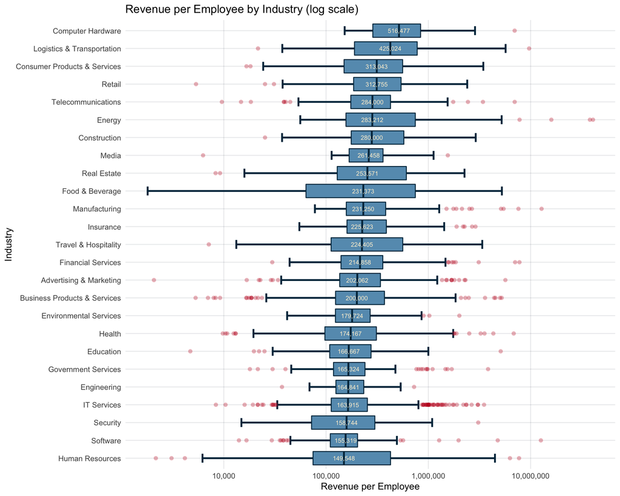

```r
# Answer Question 3 here
inc <- inc %>%
  filter(complete.cases(.)) %>%
  mutate(revenue_per_employee = Revenue / Employees)

industry.median <- summarise(group_by(inc, Industry), med = median(revenue_per_employee))
industry.median <- industry.median %>%  mutate_if(is.numeric, round)

options(scipen=10000)
ggplot(inc, aes(x=reorder(Industry, revenue_per_employee, median, na.rm = TRUE), y=revenue_per_employee)) +
    stat_boxplot(geom = "errorbar", width=0.5, size=1, color="#003049") +
    geom_boxplot(fill = "#669bbc", color="#003049", outlier.colour="#c1121f50", outlier.shape=16,
             outlier.size=2, notch=FALSE) +
             theme(panel.background = element_rect(fill = NA), panel.grid.major = element_line(colour = "#555b6e20"),
                   axis.ticks = element_blank()) +
             scale_y_log10(label = scales::comma) +
             geom_text(data = industry.median, aes(Industry, med, label = scales::comma(med)),
                       size=2.5, color="#fdf0d5") +
             coord_flip() +
             labs(title="Revenue per Employee by Industry (log scale)", x ="Industry", y = "Revenue per Employee")
```